# DATA 621 Final

Monu Chacko

5/14/2020

## COVID-19 - Impact of response to actual cases

### Abstract

Coronavirus (COVID-19) is the pandemic of our times. It spread mainly from person to person, mainly through respiratory droplets produced when an infected person coughs or sneezes. This is a new virus that has no vaccine or medicine. The only response is the invention by the states on the population. Government accross the world responsed to this pandemic is different way. In this study we will study the relationship between responses and its effect on the cases.

### Key Words

Coronavirus, COVID-19, Pandemic

### Introduction

The response to COVID-19 has an impact on the number of cases in the absence of vaccines or medicine. Governments accross the world used various measures to solve this problem. We will study the type of responses and its impact on the number of cases. We will add new features to find its possible impact.

## Import Libraries

```r
library(tidyverse)
library(moments)
library(MASS)
library(reshape2)
```

## Load data and cleanup

```r
# Load dataset
dfcovid <- read.csv(file = 'COVID19_Cases.csv')
dfcovidmd <- read.csv(file = 'cvd19metadata_1.csv')

# Rename
dfcovid <- dfcovid %>% rename("Case_Type" = "ï..Case_Type")

# Column names
# names(dfcovid)

# Drop columns that are not required
drp <- c("People_Total_Tested_Count","Difference", "Province_State Admin2", "iso2", "iso3", "FIPS", "Lat", "Long", "Province_State", "Admin2", "People_Hospitalized_Cumulative_Count", "Prep_Flow_Runtime", "Data_Source", "Combined_Key")

# Drop
dfcovid <- dfcovid[ , !(names(dfcovid) %in% drp)]

# Filter - We are only interested in confirmed cases
dfcovid <- dfcovid %>% filter(Case_Type == "Confirmed")

as_tibble(dfcovid)
```

```
## # A tibble: 387,200 x 5
##    Case_Type Cases Date      Country_Region           Population_Count
##    <fct>     <int> <fct>     <fct>                               <int>
##  1 Confirmed     0 2/3/2020  Switzerland                       8654618
##  2 Confirmed    23 4/21/2020 Antigua and Barbuda                 97928
##  3 Confirmed     0 2/6/2020  Belize                             397621
##  4 Confirmed     1 3/18/2020 Central African Republic          4829764
##  5 Confirmed  2710 5/9/2020  Greece                           10423056
##  6 Confirmed     1 3/19/2020 Central African Republic          4829764
##  7 Confirmed    18 4/29/2020 France                             285491
##  8 Confirmed     0 3/4/2020  South Sudan                      11193729
##  9 Confirmed 15970 4/27/2020 Canada                           14711827
## 10 Confirmed     0 3/28/2020 Netherlands                         26221
## # ... with 387,190 more rows
```

## Merge datasets

```r
dfcovid_mrg2 <- merge(dfcovid, dfcovidmd)
dfcovid_mrg2$CasesPerPopulation <- (dfcovid_mrg2[,3] / dfcovid_mrg2[,12]) * 10000000000

# head(dfcovid_mrg2$CasesPerPopulation)
#head(dfcovid_mrg2)

#as_tibble(dfcovid_mrg2)
```

```r
#dfcovid_region_mrg2_grp_1 <- group_by(dfcovid_mrg2, Country_Region)

#dfcovid_region_mrg2_grp_1
```

```r
# Drop columns that are not required
drp <- c("Case_Type","Date","GovtType", "GovtTypeDemocratic", "GovtTypeCentral", "Population")
dfcovid_mrg3 <- dfcovid_mrg2[ , !(names(dfcovid_mrg2) %in% drp)]

dfcovid_region_mrg2_grp <- group_by(dfcovid_mrg3, Country_Region)
dfcovid_mrg3_1 <- dfcovid_mrg3 %>% group_by(Country_Region) %>% summarise_each(funs(mean(., na.rm = TRUE)))
# df <- data.frame( ID=1:3,Date = c("2004-02-06" , "2006-03-14" , "2007-07-16") )

#dfcovid_mrg2_1 <- dfcovid_mrg2 %>% group_by(Country_Region) %>% summarise_all(funs(mean))

# by_species %>% summarise_each(funs(mean(., na.rm = TRUE)))

#dfcovid_mrg3_1


#head(dfcovid_mrg2)

dfcovid_mrg4 <- dfcovid_mrg2[c("Country_Region", "GovtType")]

dfcovid_mrg4 <- merge(dfcovid_mrg4, dfcovid_mrg3_1)

#head(dfcovid_mrg4)

#-----------------------
head(dfcovid_mrg4, 10)
```

```
##    Country_Region   GovtType    Cases Population_Count Lockdown Mask
## 1     Afghanistan Democratic 556.8727         38928341   8.7554    1
## 2     Afghanistan Democratic 556.8727         38928341   8.7554    1
## 3     Afghanistan Democratic 556.8727         38928341   8.7554    1
## 4     Afghanistan Democratic 556.8727         38928341   8.7554    1
## 5     Afghanistan Democratic 556.8727         38928341   8.7554    1
## 6     Afghanistan Democratic 556.8727         38928341   8.7554    1
## 7     Afghanistan Democratic 556.8727         38928341   8.7554    1
## 8     Afghanistan Democratic 556.8727         38928341   8.7554    1
## 9     Afghanistan Democratic 556.8727         38928341   8.7554    1
## 10    Afghanistan Democratic 556.8727         38928341   8.7554    1
##    TotalPopulation CasesPerPopulation
## 1        569377600           9780.376
## 2        569377600           9780.376
## 3        569377600           9780.376
## 4        569377600           9780.376
## 5        569377600           9780.376
## 6        569377600           9780.376
## 7        569377600           9780.376
## 8        569377600           9780.376
## 9        569377600           9780.376
## 10       569377600           9780.376
```

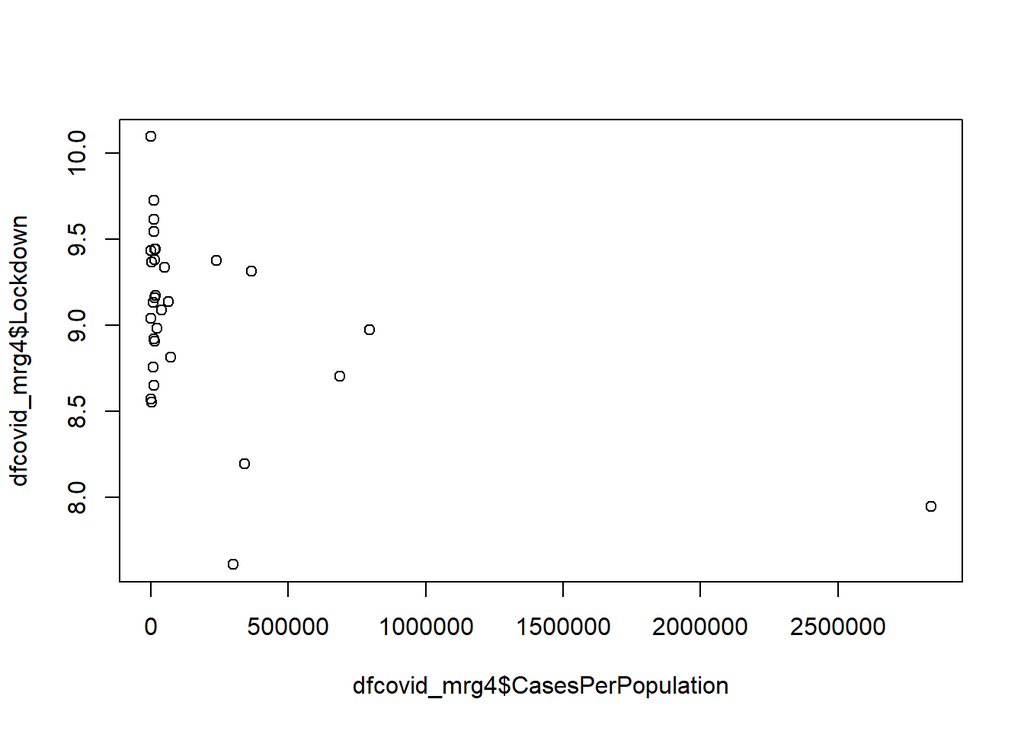

```r
plot(dfcovid_mrg4$CasesPerPopulation, dfcovid_mrg4$Lockdown)
```

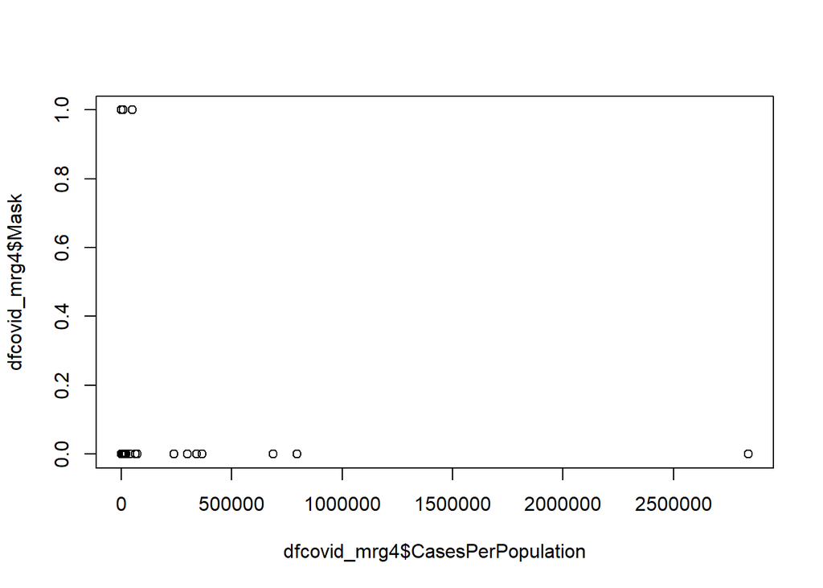

```r
plot(dfcovid_mrg4$CasesPerPopulation, dfcovid_mrg4$Mask)
```

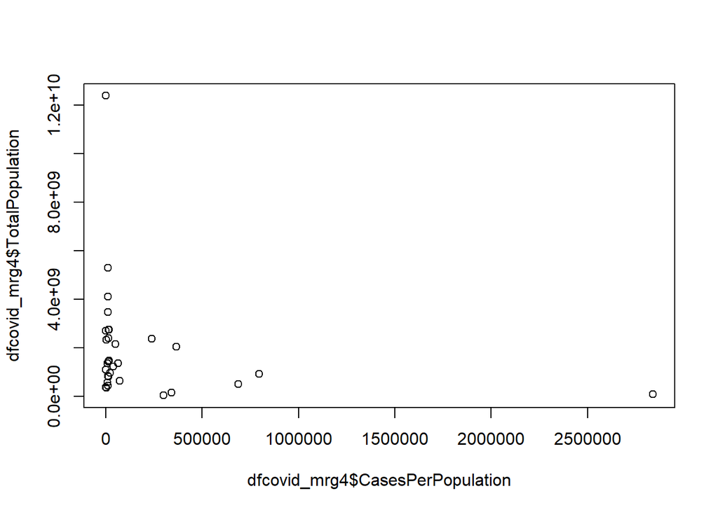

```r
plot(dfcovid_mrg4$CasesPerPopulation, dfcovid_mrg4$TotalPopulation)
```

```r
# pairs(dfcovid_mrg4)

#-----------------------

covidlm <- lm(CasesPerPopulation~Lockdown+Mask+GovtType, data=dfcovid_mrg4)

#-----------------------

summary(covidlm)
```

```
##
## Call:
## lm(formula = CasesPerPopulation ~ Lockdown + Mask + GovtType,
##     data = dfcovid_mrg4)
##
## Residuals:
##     Min      1Q  Median      3Q     Max
## -129418   -2525   -2525   -2525 2531582
##
## Coefficients:
##                     Estimate Std. Error t value Pr(>|t|)
## (Intercept)        1656671.3     7662.0  216.22   <2e-16 ***
## Lockdown           -169838.5      838.0 -202.67   <2e-16 ***
## Mask                120875.1     2908.8   41.56   <2e-16 ***
## GovtTypeDemocratic -198882.5      915.8 -217.16   <2e-16 ***
## ---
## Signif. codes:  0 '***' 0.001 '**' 0.01 '*' 0.05 '.' 0.1 ' ' 1
##
## Residual standard error: 51980 on 368716 degrees of freedom
## Multiple R-squared:  0.1387, Adjusted R-squared:  0.1387
## F-statistic: 1.979e+04 on 3 and 368716 DF,  p-value: < 2.2e-16
```

```r
# attributes(covidlm)
#abline(covidlm, col=2, lwd=3)
# Confidence Interval
confint(covidlm)
```

```
##                        2.5 %    97.5 %
## (Intercept)        1641654.1 1671688.5
## Lockdown           -171481.0 -168196.0
## Mask                115174.0  126576.2
## GovtTypeDemocratic -200677.4 -197087.5
```

```r
summary(covidlm)
```

```
##
## Call:
## lm(formula = CasesPerPopulation ~ Lockdown + Mask + GovtType,
##     data = dfcovid_mrg4)
##
## Residuals:
##     Min      1Q  Median      3Q     Max
## -129418   -2525   -2525   -2525 2531582
##
## Coefficients:
##                     Estimate Std. Error t value Pr(>|t|)
## (Intercept)        1656671.3     7662.0  216.22   <2e-16 ***
## Lockdown           -169838.5      838.0 -202.67   <2e-16 ***
## Mask                120875.1     2908.8   41.56   <2e-16 ***
## GovtTypeDemocratic -198882.5      915.8 -217.16   <2e-16 ***
## ---
## Signif. codes:  0 '***' 0.001 '**' 0.01 '*' 0.05 '.' 0.1 ' ' 1
##
## Residual standard error: 51980 on 368716 degrees of freedom
## Multiple R-squared:  0.1387, Adjusted R-squared:  0.1387
## F-statistic: 1.979e+04 on 3 and 368716 DF,  p-value: < 2.2e-16
```

```r
anova(covidlm)
```

```
## Analysis of Variance Table
##
## Response: CasesPerPopulation
##               Df     Sum Sq    Mean Sq  F value    Pr(>F)
## Lockdown       1 3.1672e+13 3.1672e+13 11722.70 < 2.2e-16 ***
## Mask           1 1.3260e+12 1.3260e+12   490.79 < 2.2e-16 ***
## GovtType       1 1.2742e+14 1.2742e+14 47160.23 < 2.2e-16 ***
## Residuals 368716 9.9618e+14 2.7018e+09
## ---
## Signif. codes:  0 '***' 0.001 '**' 0.01 '*' 0.05 '.' 0.1 ' ' 1
```

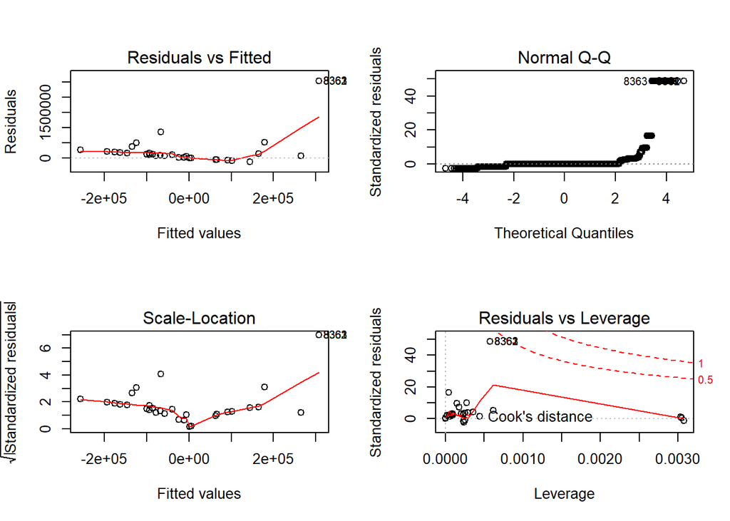

```r
par(mfrow=c(2,2))
plot(covidlm)
```

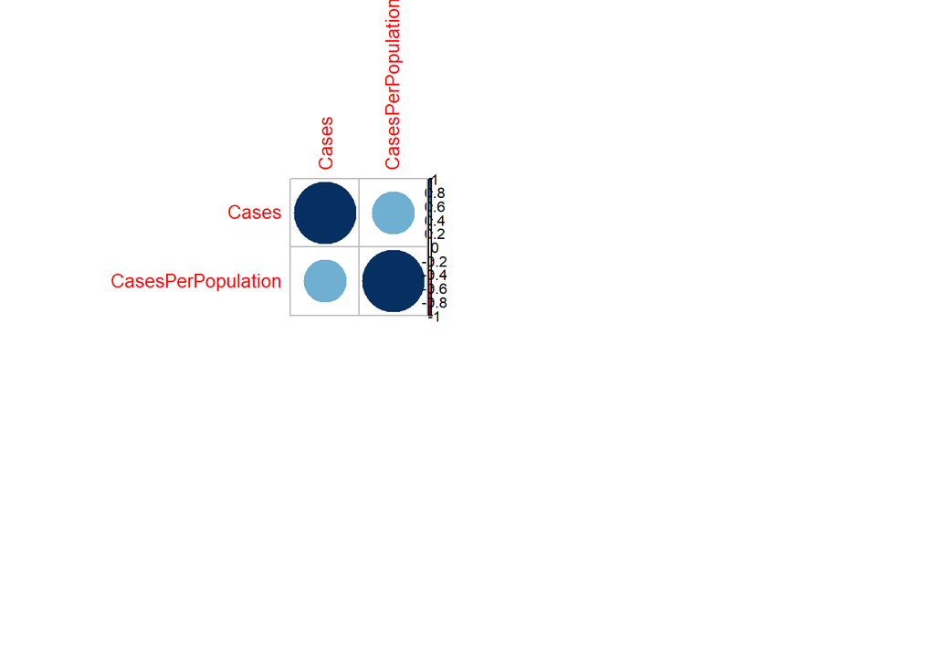

```r
#head(covidlm)
covid_mrg4_cor <- cor(dfcovid_mrg4$Cases, dfcovid_mrg4$CasesPerPopulation)
#corrplot::corrplot(covid_mrg4_cor)


dfcovid_mrg4_ss <- subset(dfcovid_mrg4, select=c(Cases, CasesPerPopulation))
#dfcovid_mrg4_ss
dfcovid_mrg4_cor <- cor(dfcovid_mrg4_ss)
#dfcovid_mrg4_cor
corrplot::corrplot(dfcovid_mrg4_cor)

#cor1 <- cor(dfcovid_mrg1_ss)

#corrplot::corrplot(cor1)



#c1 <- cor(dfcovid_mrg1$Country_Region_sum, dfcovid_mrg1$Population)

#corrplot::corrplot(cor1)
#corrplot::corrplot(cor1, method="pie")
#corrplot::corrplot(cor1, method="color")
#corrplot::corrplot(cor1, method="number")









#summarise_all(dfcovid_region_mrg2_grp, Country_Region_sum = sum(as.numeric(Population_Count), na.rm = TRUE))

dfcovid_region_mrg2_grp_s <- summarise(dfcovid_region_mrg2_grp, Country_Region_sum = sum(as.numeric(Population_Count), na.rm = TRUE))

#dfcovid_region_mrg2_grp_s
```

```r
dfcovid_region_grp <- group_by(dfcovid, Country_Region)
dfcovid_region_grp
```

```
## # A tibble: 387,200 x 5
## # Groups:   Country_Region [186]
##    Case_Type Cases Date      Country_Region           Population_Count
##    <fct>     <int> <fct>     <fct>                               <int>
##  1 Confirmed     0 2/3/2020  Switzerland                       8654618
##  2 Confirmed    23 4/21/2020 Antigua and Barbuda                 97928
##  3 Confirmed     0 2/6/2020  Belize                             397621
##  4 Confirmed     1 3/18/2020 Central African Republic          4829764
##  5 Confirmed  2710 5/9/2020  Greece                           10423056
##  6 Confirmed     1 3/19/2020 Central African Republic          4829764
##  7 Confirmed    18 4/29/2020 France                             285491
##  8 Confirmed     0 3/4/2020  South Sudan                      11193729
##  9 Confirmed 15970 4/27/2020 Canada                           14711827
## 10 Confirmed     0 3/28/2020 Netherlands                         26221
## # ... with 387,190 more rows
```

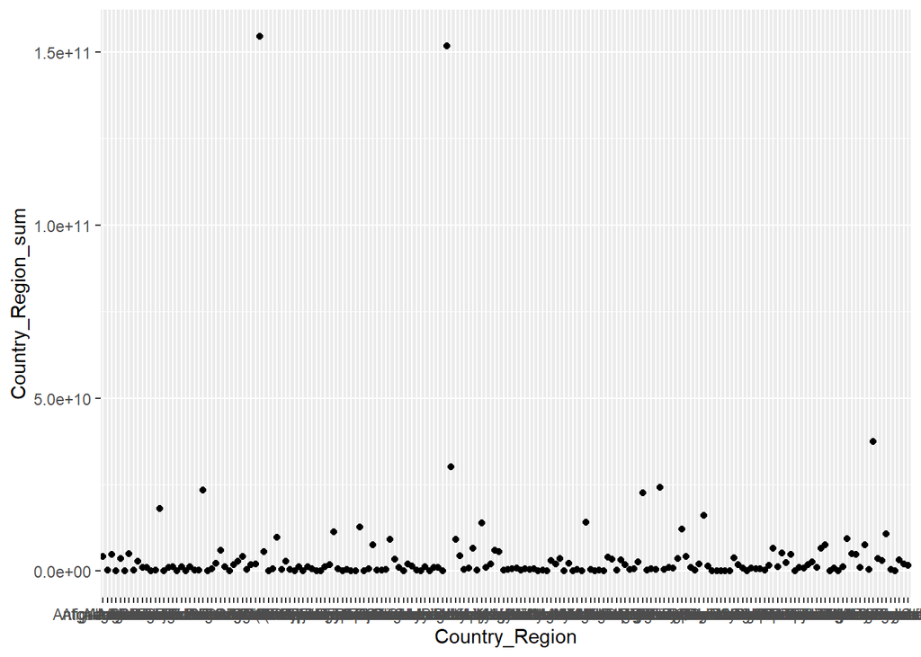

```r
dfcovid_region_grp_s <- summarise(dfcovid_region_grp, Country_Region_sum = sum(as.numeric(Population_Count), na.rm = TRUE))

ggplot(data=dfcovid_region_grp_s, aes(y=Country_Region_sum,x=Country_Region))+geom_point()
```

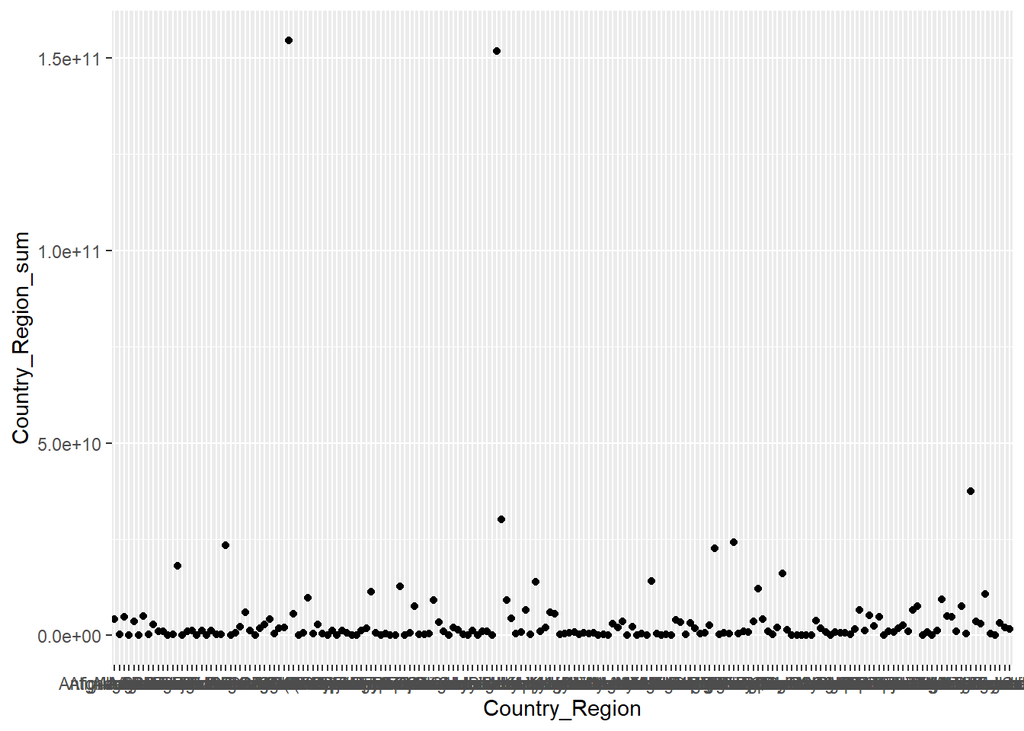

```r
# head(dfcovid, 100)

# head(dfcovid, 100)




dfcovid1 <- group_by(dfcovid, Country_Region)

dfcovid2 <- summarise(dfcovid1, Country_Region_sum = sum(as.numeric(Population_Count), na.rm = TRUE))

#dfcovid2 <- dfcovid2 %>% filter(Country_Region_sum > 50000000)

#ggplot(data=dfcovid2)
ggplot(data=dfcovid2, aes(y=Country_Region_sum,x=Country_Region))+geom_point()
```

```r
as_tibble(dfcovid2)
```

```
## # A tibble: 186 x 2
##    Country_Region      Country_Region_sum
##    <fct>                            <dbl>
##  1 Afghanistan                 4282117510
##  2 Albania                      316558000
##  3 Algeria                     4823614730
##  4 Andorra                        8499150
##  5 Angola                      3615289480
##  6 Antigua and Barbuda           10772080
##  7 Argentina                   4971535470
##  8 Armenia                      325955740
##  9 Australia                   2800567000
## 10 Austria                      990704000
## # ... with 176 more rows
```

```r
dfcovidmd
```

```
##    Country_Region  Population   GovtType GovtTypeDemocratic GovtTypeCentral
## 1     Afghanistan   56.937760 Democratic                  1               0
## 2     Switzerland  215.521378 Democratic                  1               0
## 3         Jamaica  270.993075 Democratic                  1               0
## 4          Greece   83.224732 Democratic                  1               0
## 5  United Kingdom  274.827392 Democratic                  1               0
## 6          France  122.338396 Democratic                  1               0
## 7          Canada    4.075308 Democratic                  1               0
## 8           China  143.378369    Central                  0               1
## 9        Pakistan  275.289319 Democratic                  1               0
## 10       Thailand  135.897207 Democratic                  1               0
## 11        Germany  237.370970 Democratic                  1               0
## 12        Morocco   80.728519    Central                  0               1
## 13          Italy  205.450748 Democratic                  1               0
## 14       Ethiopia  109.224559 Democratic                  1               0
```

[output cut: 49 more lines]

```r
dfcovid_mrg1 <- merge(dfcovid2, dfcovidmd)
```

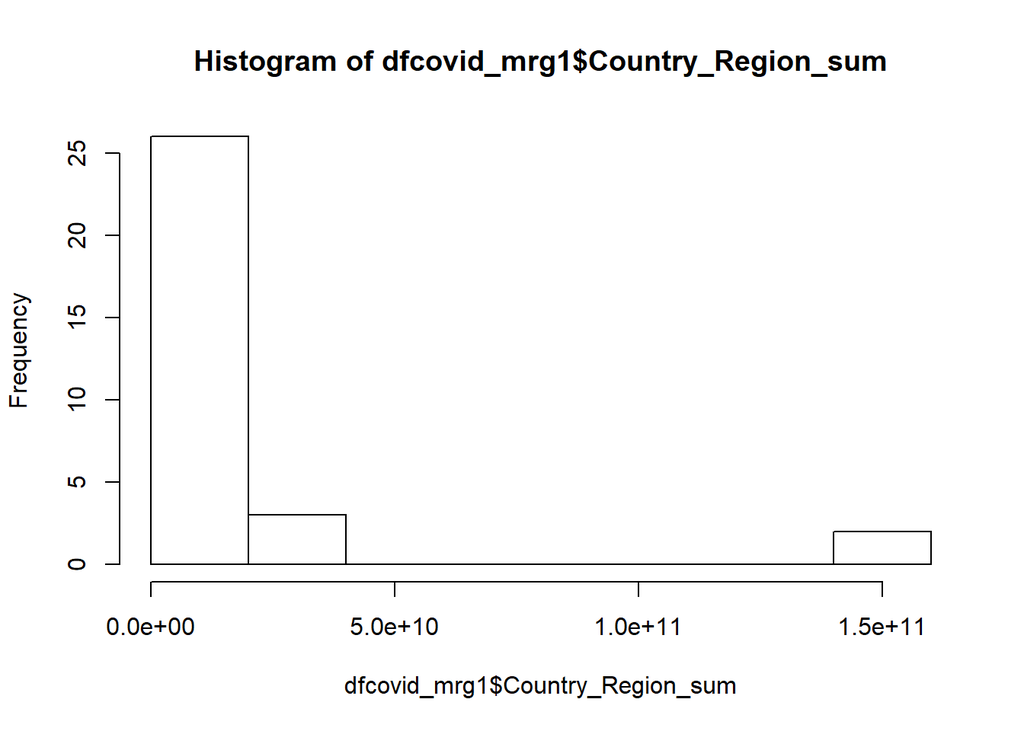

```r
#dfcovid_mrg1_ss <- subset(dfcovid_mrg1, select=c(GovtType, Population))
#dfcovid_mrg1_ss

#cor1 <- cor(dfcovid_mrg1_ss)

#corrplot::corrplot(cor1)
#corrplot::corrplot(cor1, method="pie")
#corrplot::corrplot(cor1, method="color")
#corrplot::corrplot(cor1, method="number")

#c(Country_Region_sum, GovtType, Population)

#cor1 <- subset(cor1, select=c(Country_Region_sum, GovtType, Population))

# Country_Region Country_Region_sum GovtType Population

hist(dfcovid_mrg1$Country_Region_sum)
```

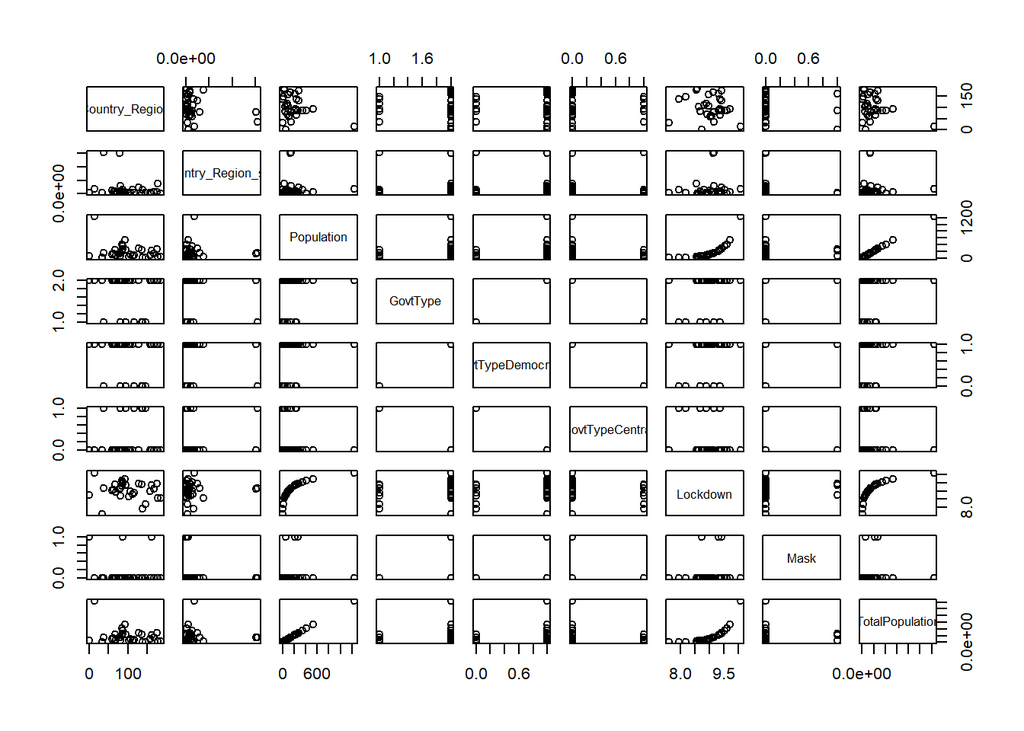

```r
plot(dfcovid_mrg1)
```

```r
plot(dfcovid_mrg1$Country_Region_sum, dfcovid_mrg1$Population)

# Perarsons coorelation (https://www.youtube.com/watch?v=66z_MRwtFJM)
c1 <- cor(dfcovid_mrg1$Country_Region_sum, dfcovid_mrg1$Population)
#corrplot::corrplot(c1, method = "square", type="upper")

# dfcovid_mrg1
rm1 <- lm(dfcovid_mrg1$Country_Region_sum ~ dfcovid_mrg1$Population)

# https://www.youtube.com/watch?v=66z_MRwtFJM
summary(rm1)
```

```
##
## Call:
## lm(formula = dfcovid_mrg1$Country_Region_sum ~ dfcovid_mrg1$Population)
##
## Residuals:
##        Min         1Q     Median         3Q        Max
## -1.845e+10 -1.548e+10 -1.085e+10 -3.864e+09  1.363e+11
##
## Coefficients:
##                           Estimate Std. Error t value Pr(>|t|)
## (Intercept)              1.898e+10  8.882e+09   2.137   0.0412 *
## dfcovid_mrg1$Population -5.179e+06  2.988e+07  -0.173   0.8636
## ---
## Signif. codes:  0 '***' 0.001 '**' 0.01 '*' 0.05 '.' 0.1 ' ' 1
##
## Residual standard error: 3.779e+10 on 29 degrees of freedom
## Multiple R-squared:  0.001035,   Adjusted R-squared:  -0.03341
## F-statistic: 0.03005 on 1 and 29 DF,  p-value: 0.8636
```

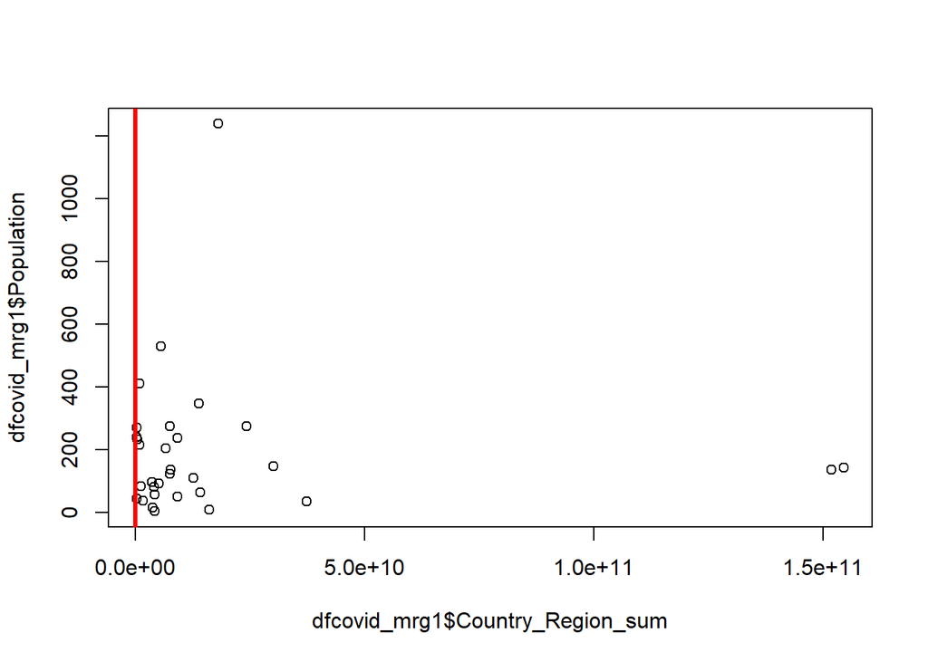

```r
# attributes(rm1)

abline(rm1, col=2, lwd=3)
```

```r
# Confidence Interval
confint(rm1)
```

```
##                             2.5 %      97.5 %
## (Intercept)             813335102 37144184911
## dfcovid_mrg1$Population -66280914    55923153
```

```r
summary(rm1)
```

```
##
## Call:
## lm(formula = dfcovid_mrg1$Country_Region_sum ~ dfcovid_mrg1$Population)
##
## Residuals:
##        Min         1Q     Median         3Q        Max
## -1.845e+10 -1.548e+10 -1.085e+10 -3.864e+09  1.363e+11
##
## Coefficients:
##                           Estimate Std. Error t value Pr(>|t|)
## (Intercept)              1.898e+10  8.882e+09   2.137   0.0412 *
## dfcovid_mrg1$Population -5.179e+06  2.988e+07  -0.173   0.8636
## ---
## Signif. codes:  0 '***' 0.001 '**' 0.01 '*' 0.05 '.' 0.1 ' ' 1
##
## Residual standard error: 3.779e+10 on 29 degrees of freedom
## Multiple R-squared:  0.001035,   Adjusted R-squared:  -0.03341
## F-statistic: 0.03005 on 1 and 29 DF,  p-value: 0.8636
```

```r
anova(rm1)
```

```
## Analysis of Variance Table
##
## Response: dfcovid_mrg1$Country_Region_sum
##                         Df     Sum Sq    Mean Sq F value Pr(>F)
## dfcovid_mrg1$Population  1 4.2909e+19 4.2909e+19  0.0301 0.8636
## Residuals               29 4.1410e+22 1.4279e+21
```

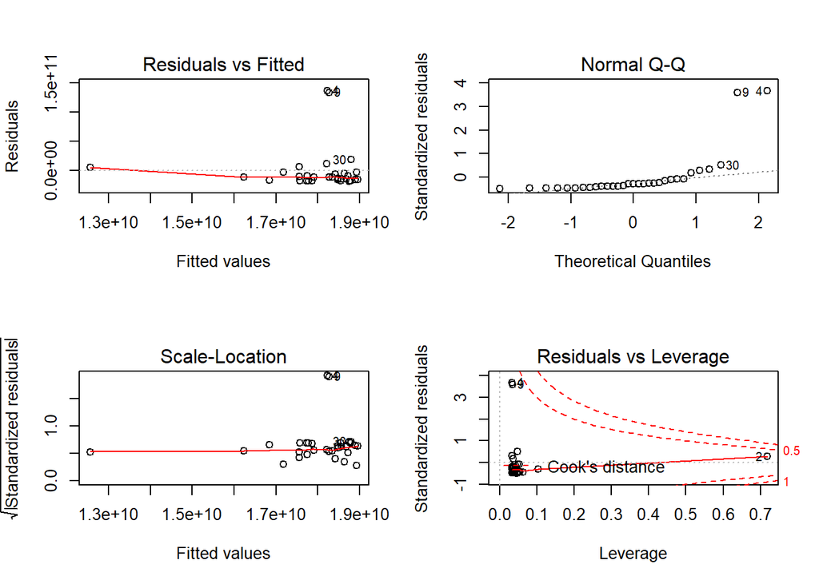

```r
# https://www.youtube.com/watch?v=eTZ4VUZHzxw

par(mfrow=c(2,2))
plot(rm1)
```

```r
# https://www.youtube.com/watch?v=TgVx9Rqsewo (Box-Cox 1)
# https://www.youtube.com/watch?v=6O_9QUeyBVU (Box-Cox 2)
skewness(rm1$resid)
```

```
## [1] 3.206512
```

```r
boxcox_rm1 <- boxcox(dfcovid_mrg1$Country_Region_sum ~ dfcovid_mrg1$Population)

# Rearrange and put it side by side
lmda <- boxcox_rm1$x
lik <- boxcox_rm1$y
bc <- cbind(lmda, lik)
bc[order(-lik), ]
```

```
##               lmda        lik
##   [1,]  0.02020202  -67.51210
##   [2,] -0.02020202  -67.56604
##   [3,]  0.06060606  -67.63425
##   [4,] -0.06060606  -67.79095
##   [5,]  0.10101010  -67.93609
##   [6,] -0.10101010  -68.18016
##   [7,]  0.14141414  -68.42038
##   [8,] -0.14141414  -68.72666
##   [9,]  0.18181818  -69.08690
##  [10,] -0.18181818  -69.42252
##  [11,]  0.22222222  -69.93465
##  [12,] -0.22222222  -70.25955
##  [13,]  0.26262626  -70.96044
##  [14,] -0.26262626  -71.22960
```

[output cut: 86 more lines]

```r
# https://www.youtube.com/watch?v=q1RD5ECsSB0 (Multiple Linear Regression in R)
```

```r
#cv_df_all_countries = cv_df_raw.copy()

# Prepare data for analysis
#cv_df_all_countries = cv_df_all_countries.drop(columns=["Difference", "Province_State", "Admin2", "iso2",  "iso3", "Combined_Key", "Prep_Flow_Runtime", "Lat", "Long", "FIPS", "People_Total_Tested_Count", "Population_Count", "People_Hospitalized_Cumulative_Count", "Data_Source", "Date"])
#cv_df_all_countries = cv_df_all_countries[(cv_df_all_countries["Case_Type"] == "Confirmed")]
#cv_df_all_countries_summary = cv_df_all_countries.groupby(["Country_Region"])["Cases"].sum().rename("Total_Cases").reset_index()

# Filter to reduce noise
#cv_df_all_countries_summary = cv_df_all_countries_summary[(cv_df_all_countries_summary["Total_Cases"] > 500000)]
```

Box-Cox: https://www.youtube.com/watch?v=TgVx9Rqsewo

Population Density (https://data.worldbank.org/indicator/EN.POP.DNST)